# Chapter 8 Regression Models for Quantitative and Qualitative Predictors

Bryan Goodrich

2015-08-08

# Chapter 8 – Regression Models for Quantitative and Qualitative Predictors

## Load the data sets

```r
library(car)    # Used by alr3
library(alr3)   # pureErrorAnova
library(Rcmdr)  # scatter3d

data("CH08TA01", package = "ALSM")
data("CH07TA01", package = "ALSM")
data("CH08TA02", package = "ALSM")
data("CH08TA05", package = "ALSM")
```

## Input the Power Cells Data

```r
.data <- CH08TA01
names(.data) <- c("Y", "X1", "X2")
.data <- transform(.data,
  x1   = scale(X1, scale = 0.4),
  x2   = scale(X2, scale = 10),
  x1sq = scale(X1, scale = 0.4)^2,
  x2sq = scale(X2, scale = 10)^2,
  x1x2 = scale(X1,, 0.4) * scale(X2,, 10))

fit <- lm(Y ~ ., .data)
```

## Table 8.1 (p 300)

#### Data–Power Cells Example

```r
model.frame(.data)
```

```
##      Y  X1 X2 x1 x2 x1sq x2sq x1x2
## 1  150 0.6 10 -1 -1    1    1    1
## 2   86 1.0 10  0 -1    0    1    0
## 3   49 1.4 10  1 -1    1    1   -1
## 4  288 0.6 20 -1  0    1    0    0
## 5  157 1.0 20  0  0    0    0    0
## 6  131 1.0 20  0  0    0    0    0
## 7  184 1.0 20  0  0    0    0    0
## 8  109 1.4 20  1  0    1    0    0
## 9  279 0.6 30 -1  1    1    1   -1
## 10 235 1.0 30  0  1    0    1    0
## 11 224 1.4 30  1  1    1    1    1
```

## FIGURE 8.5 (p 303)

#### Diagnostic Residual Plots–Power Cells Example

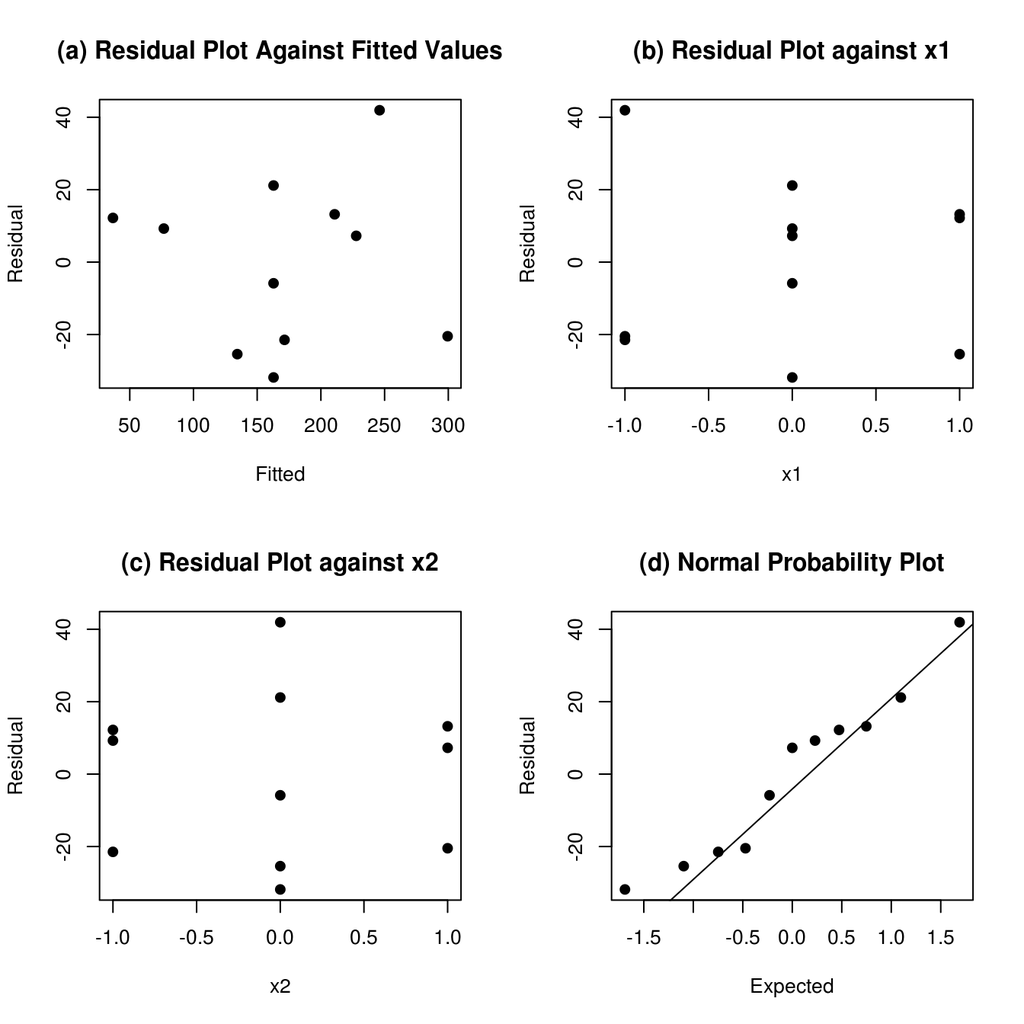

```r
par(mfrow = c(2, 2), pch = 19)
plot(resid(fit) ~ fitted(fit), xlab = "Fitted", ylab = "Residual")
title("(a) Residual Plot Against Fitted Values")

plot(resid(fit) ~ x1, .data, xlab = "x1", ylab = "Residual")
title("(b) Residual Plot against x1")

plot(resid(fit) ~ x2, .data, xlab = "x2", ylab = "Residual")
title("(c) Residual Plot against x2")

qqnorm(resid(fit), xlab = "Expected", ylab = "Residual", main = "")
qqline(resid(fit))
title("(d) Normal Probability Plot")
```

## FIGURE 8.4 (p 301-5)

#### Regression Output for Second-Order Polynomial Model–Power Cells Example

A lot of analysis was performed over these pages, both shown and not shown. For that reason I will follow a similar process. However, results that can be easily obtained by summary functions will be ignored. The F-test that is performed is not that in the summary results (either here or in the SAS output the authors provide). The summary results show the F-test as to whether or not all the predictor variables are relevant. This statistic is `10.57`, which is still less than the 19.2. Recall from Chapter 3 that the *alr3* library contains `pureErrorAnova` for an extended ANOVA table.

```r
fit <- lm(Y ~ ., .data)                                 # Restate the model
summary(fit)
```

```
##
## Call:
## lm(formula = Y ~ ., data = .data)
##
## Residuals:
##      1      2      3      4      5      6      7      8      9     10
## -21.46   9.26  12.20  41.93  -5.84 -31.84  21.16 -25.40 -20.46   7.26
##     11
##  13.20
##
## Coefficients: (2 not defined because of singularities)
##             Estimate Std. Error t value Pr(>|t|)
## (Intercept)   151.43      45.46    3.33   0.0208 *
## X1           -139.58      33.04   -4.22   0.0083 **
## X2              7.55       1.32    5.71   0.0023 **
## x1                NA         NA      NA       NA
## x2                NA         NA      NA       NA
## x1sq           27.39      20.34    1.35   0.2359
## x2sq          -10.61      20.34   -0.52   0.6244
## x1x2           11.50      16.19    0.71   0.5092
## ---
## Signif. codes:  0 '***' 0.001 '**' 0.01 '*' 0.05 '.' 0.1 ' ' 1
##
## Residual standard error: 32.4 on 5 degrees of freedom
## Multiple R-squared:  0.914,  Adjusted R-squared:  0.827
## F-statistic: 10.6 on 5 and 5 DF,  p-value: 0.0109
```

```r
pureErrorAnova(fit)                                     # alr3 function
```

```
## Analysis of Variance Table
##
## Response: Y
##              Df Sum Sq Mean Sq F value Pr(>F)
## X1            1  18704   18704   26.63  0.036 *
## X2            1  34201   34201   48.70  0.020 *
## x1sq          1   1646    1646    2.34  0.265
## x2sq          1    285     285    0.41  0.589
## x1x2          1    529     529    0.75  0.477
## Residuals     5   5240    1048
##  Lack of fit  3   3836    1279    1.82  0.374
##  Pure Error   2   1405     702
## ---
## Signif. codes:  0 '***' 0.001 '**' 0.01 '*' 0.05 '.' 0.1 ' ' 1
```

```r
anova(lm(Y ~ 1, .data), fit)                            # Explicit F-Test
```

```
## Analysis of Variance Table
##
## Model 1: Y ~ 1
## Model 2: Y ~ X1 + X2 + x1 + x2 + x1sq + x2sq + x1x2
##   Res.Df   RSS Df Sum of Sq    F Pr(>F)
## 1     10 60606
## 2      5  5240  5     55366 10.6  0.011 *
## ---
## Signif. codes:  0 '***' 0.001 '**' 0.01 '*' 0.05 '.' 0.1 ' ' 1
```

```r
# Calculate F*     (p 302)
pureErrorAnova(fit)[" Lack of fit", "Mean Sq"] / pureErrorAnova(fit)[" Pure Error",  "Mean Sq"]  # (6.68b)
```

```
## [1] 1.82
```

```r
# Correlation (p 301)
with(.data, rbind(
  "X and Xsq" = round(c("1" = cor(X1, X1^2), "2" = cor(X2, X2^2)), 3),
  "x and xsq" = round(c("1" = cor(x1, x1^2), "2" = cor(x2, x2^2)), 3)))
```

```
##               1     2
## X and Xsq 0.991 0.986
## x and xsq 0.000 0.000
```

```r
anova(lm(Y ~ x1 + x2, .data), fit)                      # partial F-test
```

```
## Analysis of Variance Table
##
## Model 1: Y ~ x1 + x2
## Model 2: Y ~ X1 + X2 + x1 + x2 + x1sq + x2sq + x1x2
##   Res.Df  RSS Df Sum of Sq    F Pr(>F)
## 1      8 7700
## 2      5 5240  3      2460 0.78   0.55
```

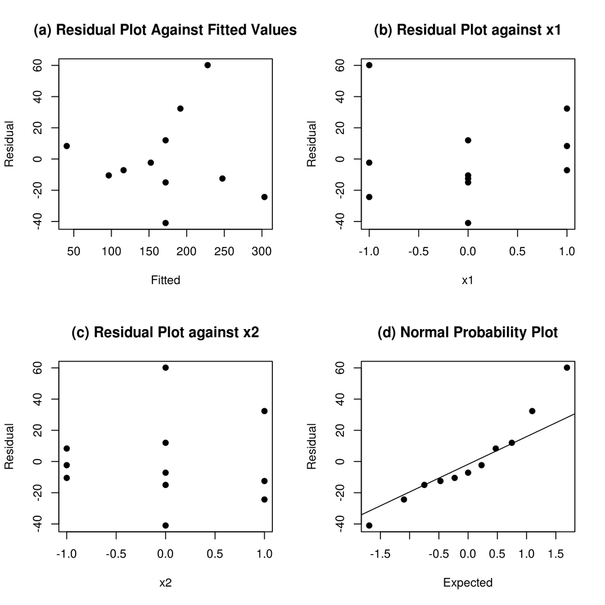

```r
fit <- lm(Y ~ x1 + x2, .data)                           # refit model (p 304)

# Diagnostic Plots
par(mfrow = c(2, 2), pch = 19)                       # Same as FIGURE 8.5
plot(resid(fit) ~ fitted(fit), xlab = "Fitted", ylab = "Residual")
title("(a) Residual Plot Against Fitted Values")

plot(resid(fit) ~ x1, .data, xlab = "x1", ylab = "Residual")
title("(b) Residual Plot against x1")

plot(resid(fit) ~ x2, .data, xlab = "x2", ylab = "Residual")
title("(c) Residual Plot against x2")

qqnorm(resid(fit), xlab = "Expected", ylab = "Residual", main = "")
title("(d) Normal Probability Plot")
qqline(resid(fit))
```

```r
confint(lm(Y ~ X1 + X2, .data))                         # Bonferroni procedure on original coefs. (p 305)
```

```
##                2.5 % 97.5 %
## (Intercept)   64.618 256.55
## X1          -212.602 -66.56
## X2             4.629  10.47
```

## FIGURE 8.6 (p 304)

#### Plot of Fitted Response Plane–Power Cells Example

Here we make use of the function I defined in chapter 6 for `FIGURE 6.7`.

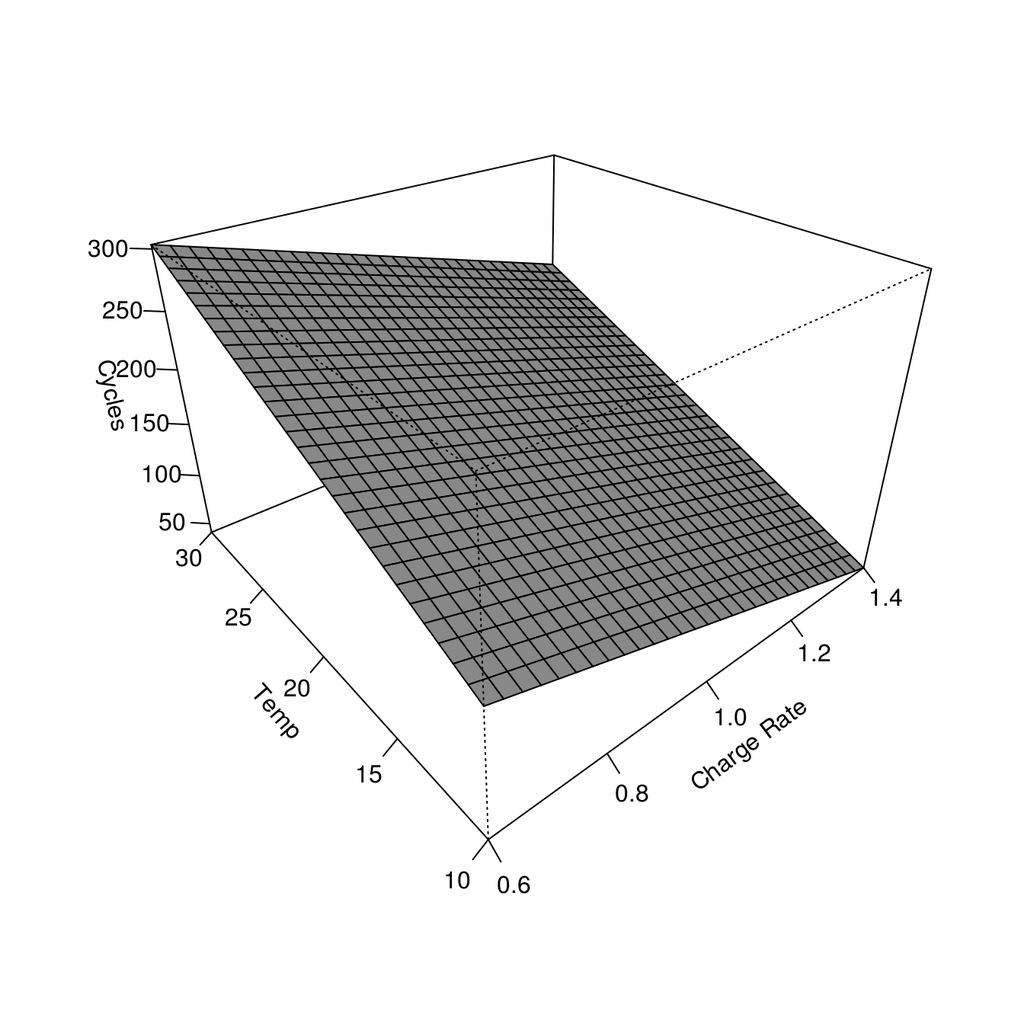

```r
lm3d <- function(model, res, ...) {
  ivs <- labels(terms(model))
  x <- model.frame(model)[, ivs[1]]     # 1st independent variable
  y <- model.frame(model)[, ivs[2]]     # 2nd independent variable
  xr <- seq(min(x), max(x), len = res)  # equidistant sequence from range of 1st iv
  yr <- seq(min(y), max(y), len = res)  # equidistant sequence from range of 2nd iv

  # Create a list object of these sequences to be turned into a grid
  newdata <- list(xr, yr)
  names(newdata) <- ivs
  newdata <- do.call('expand.grid', newdata)

  zr <- matrix(predict(model, newdata), res, res)
  persp(xr, yr, zr, ...)
}

lm3d(lm(Y ~ X1 + X2, .data), res = 30, ticktype = "detailed", shade = 0.5, expand = 2/3,
     xlab = "Charge Rate", ylab = "Temp", zlab = "Cycles",
     theta = 320, phi = 30)
```

## Input the Body Fat Data

```r
.data <- CH07TA01
names(.data) <- c("X1", "X2", "X3", "Y")

# Add centered variables
.data <- transform(.data,
  x1 = scale(X1, T, F),
  x2 = scale(X2, T, F),
  x3 = scale(X3, T, F))

fit <- lm(Y ~ (X1 + X2 + X3)^2, .data)
```

## Implementation of Interaction Regression Models (p 312-3)

#### Body Fat Example

```r
cor(model.matrix(fit)[, -1])         # Interactions, high correlation (p 312)
```

```
##           X1      X2      X3  X1:X2  X1:X3  X2:X3
## X1    1.0000 0.92384 0.45778 0.9888 0.9003 0.8907
## X2    0.9238 1.00000 0.08467 0.9663 0.6720 0.6536
## X3    0.4578 0.08467 1.00000 0.3324 0.7877 0.8064
## X1:X2 0.9888 0.96634 0.33239 1.0000 0.8345 0.8219
## X1:X3 0.9003 0.67197 0.78770 0.8345 1.0000 0.9984
## X2:X3 0.8907 0.65361 0.80641 0.8219 0.9984 1.0000
```

```r
fit <- lm(Y ~ (x1 + x2 + x3)^2, .data)  # fit centered values instead
cor(model.matrix(fit)[, -1])         # less correlation, but still present
```

```
##            x1       x2       x3   x1:x2    x1:x3   x2:x3
## x1     1.0000  0.92384  0.45778 -0.4770 -0.17342 -0.2216
## x2     0.9238  1.00000  0.08467 -0.4298 -0.17254 -0.1437
## x3     0.4578  0.08467  1.00000 -0.2159 -0.03041 -0.2354
## x1:x2 -0.4770 -0.42979 -0.21589  1.0000  0.23283  0.2919
## x1:x3 -0.1734 -0.17254 -0.03041  0.2328  1.00000  0.8905
## x2:x3 -0.2216 -0.14366 -0.23537  0.2919  0.89051  1.0000
```

```r
summary(fit)
```

```
##
## Call:
## lm(formula = Y ~ (x1 + x2 + x3)^2, data = .data)
##
## Residuals:
##    Min     1Q Median     3Q    Max
## -3.927 -0.873  0.168  1.293  3.331
##
## Coefficients:
##             Estimate Std. Error t value Pr(>|t|)
## (Intercept) 20.52689    1.07363   19.12  6.7e-11 ***
## x1           3.43781    3.57867    0.96     0.35
## x2          -2.09472    3.03677   -0.69     0.50
## x3          -1.61634    1.90721   -0.85     0.41
## x1:x2        0.00888    0.03085    0.29     0.78
## x1:x3       -0.08479    0.07342   -1.15     0.27
## x2:x3        0.09042    0.09200    0.98     0.34
## ---
## Signif. codes:  0 '***' 0.001 '**' 0.01 '*' 0.05 '.' 0.1 ' ' 1
##
## Residual standard error: 2.6 on 13 degrees of freedom
## Multiple R-squared:  0.823,  Adjusted R-squared:  0.741
## F-statistic: 10.1 on 6 and 13 DF,  p-value: 0.000296
```

```r
anova(fit)
```

```
## Analysis of Variance Table
##
## Response: Y
##           Df Sum Sq Mean Sq F value    Pr(>F)
## x1         1    352     352   52.22 0.0000067 ***
## x2         1     33      33    4.92     0.045 *
## x3         1     12      12    1.71     0.213
## x1:x2      1      1       1    0.22     0.646
## x1:x3      1      3       3    0.40     0.538
## x2:x3      1      7       7    0.97     0.344
## Residuals 13     88       7
## ---
## Signif. codes:  0 '***' 0.001 '**' 0.01 '*' 0.05 '.' 0.1 ' ' 1
```

```r
anova(lm(Y ~ x1 + x2 + x3, .data), fit) # partial F-test: F = 0.53 < qf(.95, 3,13)
```

```
## Analysis of Variance Table
##
## Model 1: Y ~ x1 + x2 + x3
## Model 2: Y ~ (x1 + x2 + x3)^2
##   Res.Df  RSS Df Sum of Sq    F Pr(>F)
## 1     16 98.4
## 2     13 87.7  3      10.7 0.53   0.67
```

## Input the Insurance Innovation Data

```r
.data <- CH08TA02
names(.data) <- c("Y", "X1", "X2")
.data <- transform(.data, X2 = factor(X2, labels = c("Mutual", "Stock")))
fit <- lm(Y ~ X1 + X2, .data)
```

## FIGURE 8.11 (p 316)

#### Plot of Y against X1 at both levels of indicator variable–Insurance Innovation Example

When using `abline` on a fitted model, it is really just supplying the slope and intercept coefficients to the relevant parameters. We can use this fact to adjust those parameters for the two situations. In particular, the default parameters to `abline` are of the form

> `abline(intercept, slope)`

Under a qualitative predictor, when it is not the reference level, we see that coefficient addition to the intercept term. This is what we mimic below given how `abline` works.

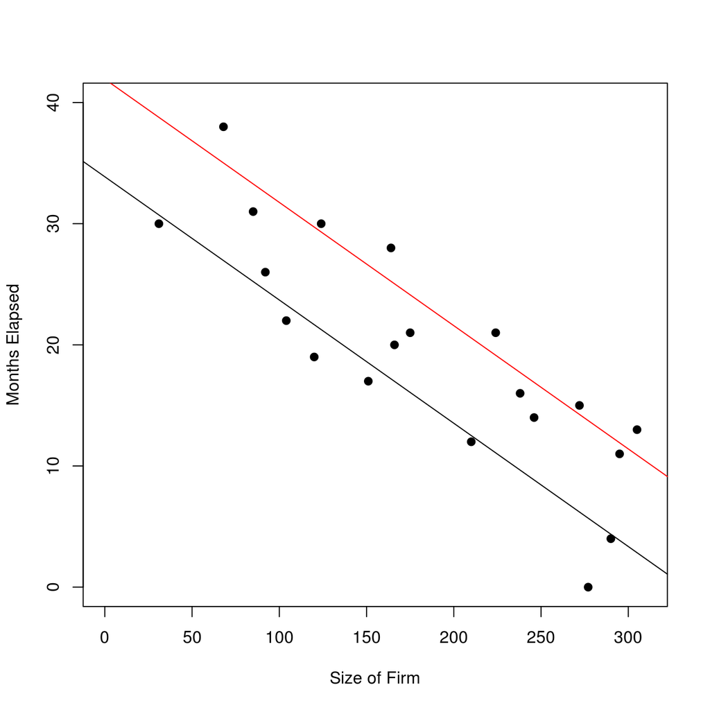

```r
plot(Y ~ X1, .data, pch = 19, ylim = c(0, 40), xlim = c(0, 310),
     xlab = "Size of Firm", ylab = "Months Elapsed")

abline(coef(fit)[[1]], coef(fit)[[2]],)  # Mutual Firm
abline(coef(fit)[[1]] + coef(fit)[[3]], coef(fit)[[2]], col = "red")  # Stock  Firm
```

## TABLE 8.2 (p 317)

#### Data and Indicator Coding–Insurance Innovation Example

If you simply tried to `cbind` a factor value, it will return the way R stores it as 1 and 2. There are 2 approaches used below to access the information we want. First, we can use the `model.matrix` for the fitted model. This returns the `X` matrix used in the linear model which contains the binary encoding for a dummy variable (multiple columns for multiple category predictor). The other approach is to realize that if you remove the class (`unclass`) from that variable, it returns as the storage 1 and 2 values, numerically. We can then offset that by 1 to get a binary encoding as desired. This is performed below to obtain the interaction terms.

```r
data.frame(
    "Months"      = .data$Y,
    "Firm Size"   = .data$X1,
    "Firm Type"   = .data$X2,
    "Indicator"   = model.matrix(fit)[, 3],
    "Interaction" = .data$X1 * (unclass(.data$X2) - 1)
)
```

```
##    Months Firm.Size Firm.Type Indicator Interaction
## 1      17       151    Mutual         0           0
## 2      26        92    Mutual         0           0
## 3      21       175    Mutual         0           0
## 4      30        31    Mutual         0           0
## 5      22       104    Mutual         0           0
## 6       0       277    Mutual         0           0
## 7      12       210    Mutual         0           0
## 8      19       120    Mutual         0           0
## 9       4       290    Mutual         0           0
## 10     16       238    Mutual         0           0
## 11     28       164     Stock         1         164
## 12     15       272     Stock         1         272
## 13     11       295     Stock         1         295
## 14     38        68     Stock         1          68
## 15     31        85     Stock         1          85
## 16     21       224     Stock         1         224
## 17     20       166     Stock         1         166
## 18     13       305     Stock         1         305
## 19     30       124     Stock         1         124
## 20     14       246     Stock         1         246
```

## TABLE 8.3 (p 317)

#### Regression Results for Fit of Regression Model (8.33)–Insurance Innovation Example

Also included are the results for the confidence intervals of the parameters. The formal test is inherent in `summary` as the p-values and printed stars demonstrate these coeffficients are significant at an `alpha = 0.01` level. This is confirmed by the respective confidence interval not including zero.

```r
summary(fit)
```

```
##
## Call:
## lm(formula = Y ~ X1 + X2, data = .data)
##
## Residuals:
##    Min     1Q Median     3Q    Max
## -5.692 -1.704 -0.439  1.921  6.341
##
## Coefficients:
##             Estimate Std. Error t value Pr(>|t|)
## (Intercept) 33.87407    1.81386   18.68  9.1e-13 ***
## X1          -0.10174    0.00889  -11.44  2.1e-09 ***
## X2Stock      8.05547    1.45911    5.52  3.7e-05 ***
## ---
## Signif. codes:  0 '***' 0.001 '**' 0.01 '*' 0.05 '.' 0.1 ' ' 1
##
## Residual standard error: 3.22 on 17 degrees of freedom
## Multiple R-squared:  0.895,  Adjusted R-squared:  0.883
## F-statistic: 72.5 on 2 and 17 DF,  p-value: 4.77e-09
```

```r
anova(fit)
```

```
## Analysis of Variance Table
##
## Response: Y
##           Df Sum Sq Mean Sq F value  Pr(>F)
## X1         1   1188    1188   114.5 5.7e-09 ***
## X2         1    316     316    30.5 3.7e-05 ***
## Residuals 17    176      10
## ---
## Signif. codes:  0 '***' 0.001 '**' 0.01 '*' 0.05 '.' 0.1 ' ' 1
```

```r
confint(fit)
```

```
##               2.5 %   97.5 %
## (Intercept) 30.0472 37.70098
## X1          -0.1205 -0.08298
## X2Stock      4.9770 11.13391
```

## FIGURE 8.12 (p 318)

#### Fitted Regression Function for Regression Model (8.33)–Insurance Innovation Example

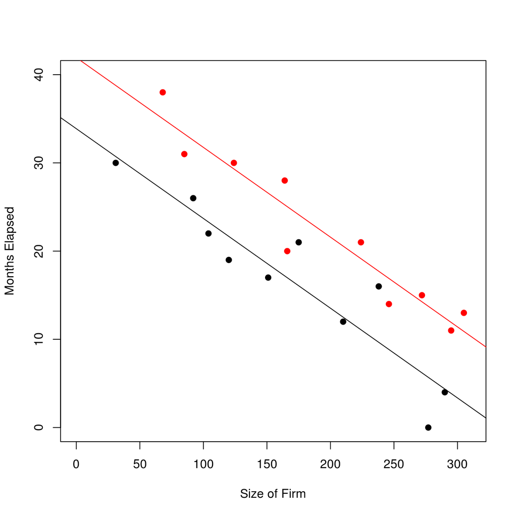

```r
fit <- lm(Y ~ X1 + X2, .data)
plot(Y ~ X1, .data, col = X2, pch = 19, ylim = c(0, 40), xlim = c(0, 310),
     xlab = "Size of Firm", ylab = "Months Elapsed")
abline(coef(fit)[[1]], coef(fit)[[2]])  # Mutual Firm
abline(coef(fit)[[1]] + coef(fit)[[3]],  coef(fit)[[2]], col = "red")  # Stock  Firm
```

## FIGURE 8.14 and FIGURE 8.15 (p 325)

#### Plot of Y against X1 at both levels of indicator variable–Insurance Innovation Example

Note that the author does an illustration that exaggerates the change in slope. As is evidenced from this example, the slope is relatively unchanged so that the two lines appear parallel. The difference between the two is the coefficient `X1X2 = -0.000417`

Here I set a new model that nests the `X2` levels. By excluding the intercept term, the coefficients 1 and 3 apply to the first `X2` level (mutual firm) and the coefficients 2 and 4 apply to the second `X2` level (stock firm).

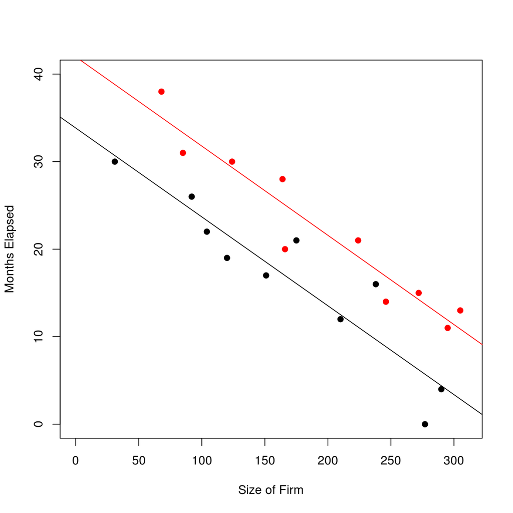

```r
fit <- lm(Y ~ X2/X1 - 1, .data)  # Using nested model for ease of presentation
plot(Y ~ X1, .data, col = X2, pch = 19, ylim = c(0, 40), xlim = c(0, 310),
     xlab = "Size of Firm", ylab = "Months Elapsed")
abline(coef(fit)[[1]], coef(fit)[[3]])               # Mutual Firm
abline(coef(fit)[[2]], coef(fit)[[4]], col = "red")  # Stock  Firm
```

## TABLE 8.4 (p 327)

#### Regression Results for Fit of Regression Model (8.49) with Interaction Term–Insurance Innovation Example

```r
fit <- lm(Y ~ X1 * X2, .data)  # Going back to intended model
summary(fit)
```

```
##
## Call:
## lm(formula = Y ~ X1 * X2, data = .data)
##
## Residuals:
##    Min     1Q Median     3Q    Max
## -5.714 -1.706 -0.456  1.931  6.326
##
## Coefficients:
##              Estimate Std. Error t value Pr(>|t|)
## (Intercept) 33.838369   2.440650   13.86  2.5e-10 ***
## X1          -0.101531   0.013053   -7.78  8.0e-07 ***
## X2Stock      8.131250   3.654052    2.23    0.041 *
## X1:X2Stock  -0.000417   0.018331   -0.02    0.982
## ---
## Signif. codes:  0 '***' 0.001 '**' 0.01 '*' 0.05 '.' 0.1 ' ' 1
##
## Residual standard error: 3.32 on 16 degrees of freedom
## Multiple R-squared:  0.895,  Adjusted R-squared:  0.875
## F-statistic: 45.5 on 3 and 16 DF,  p-value: 4.67e-08
```

```r
anova(fit)
```

```
## Analysis of Variance Table
##
## Response: Y
##           Df Sum Sq Mean Sq F value  Pr(>F)
## X1         1   1188    1188   107.8 1.6e-08 ***
## X2         1    316     316    28.7 6.4e-05 ***
## X1:X2      1      0       0     0.0    0.98
## Residuals 16    176      11
## ---
## Signif. codes:  0 '***' 0.001 '**' 0.01 '*' 0.05 '.' 0.1 ' ' 1
```

```r
anova(lm(Y ~ X1 + X2, .data), fit)
```

```
## Analysis of Variance Table
##
## Model 1: Y ~ X1 + X2
## Model 2: Y ~ X1 * X2
##   Res.Df RSS Df Sum of Sq  F Pr(>F)
## 1     17 176
## 2     16 176  1   0.00571  0   0.98
```

## Input the Soap Production Lines Data

```r
.data <- CH08TA05
names(.data) <- c("Y", "X1", "X2")
.data <- transform(.data, X2 = factor(X2, labels = c("Line1", "Line2")))
```

## TABLE 8.5 (p 330)

#### Data–Soap Production Lines Example

```r
data.frame(
  "Scrap"      = .data$Y,
  "Line_Speed" = .data$X1,
  "Indicator"  = .data$X2)
```

```
##    Scrap Line_Speed Indicator
## 1    218        100     Line2
## 2    248        125     Line2
## 3    360        220     Line2
## 4    351        205     Line2
## 5    470        300     Line2
## 6    394        255     Line2
## 7    332        225     Line2
## 8    321        175     Line2
## 9    410        270     Line2
## 10   260        170     Line2
## 11   241        155     Line2
## 12   331        190     Line2
## 13   275        140     Line2
## 14   425        290     Line2
## 15   367        265     Line2
## 16   140        105     Line1
## 17   277        215     Line1
## 18   384        270     Line1
## 19   341        255     Line1
## 20   215        175     Line1
## 21   180        135     Line1
## 22   260        200     Line1
## 23   361        275     Line1
## 24   252        155     Line1
## 25   422        320     Line1
## 26   273        190     Line1
## 27   410        295     Line1
```

## FIGURE 8.16 (p 331)

#### Symbolic Scatter Plot–Soap Production Lines Example

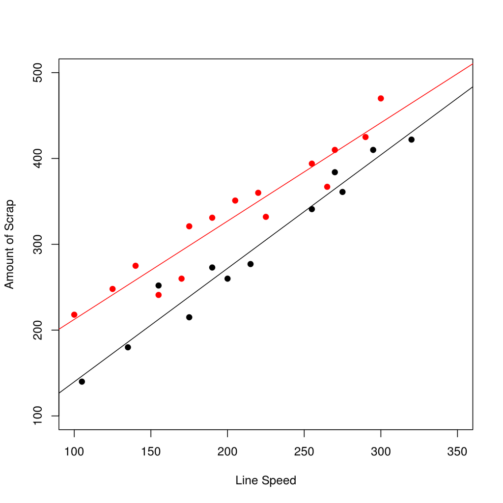

```r
fit <- lm(Y ~ X2/X1 - 1, .data)  # Using nested model for ease of presentation
plot(Y ~ X1, .data, col = X2, ylim = c(100, 500), xlim = c(100, 350), pch = 19,
     xlab = "Line Speed", ylab = "Amount of Scrap")
abline(coef(fit)[[1]], coef(fit)[[3]])               # Production Line 1
abline(coef(fit)[[2]], coef(fit)[[4]], col = "red")  # Production Line 2
```

## FIGURE 8.17 (p 332)

#### Residual Plots against Yhat–Soap Production Lines Example

The author mentions a residual plot against X2 and a normal probability plot (page 331), but did not include them. I have included them below. Note that ‘fit’ is still referring to the fitted model, but the results are the same as `lm(Y ~ X1*X2, .data)`.

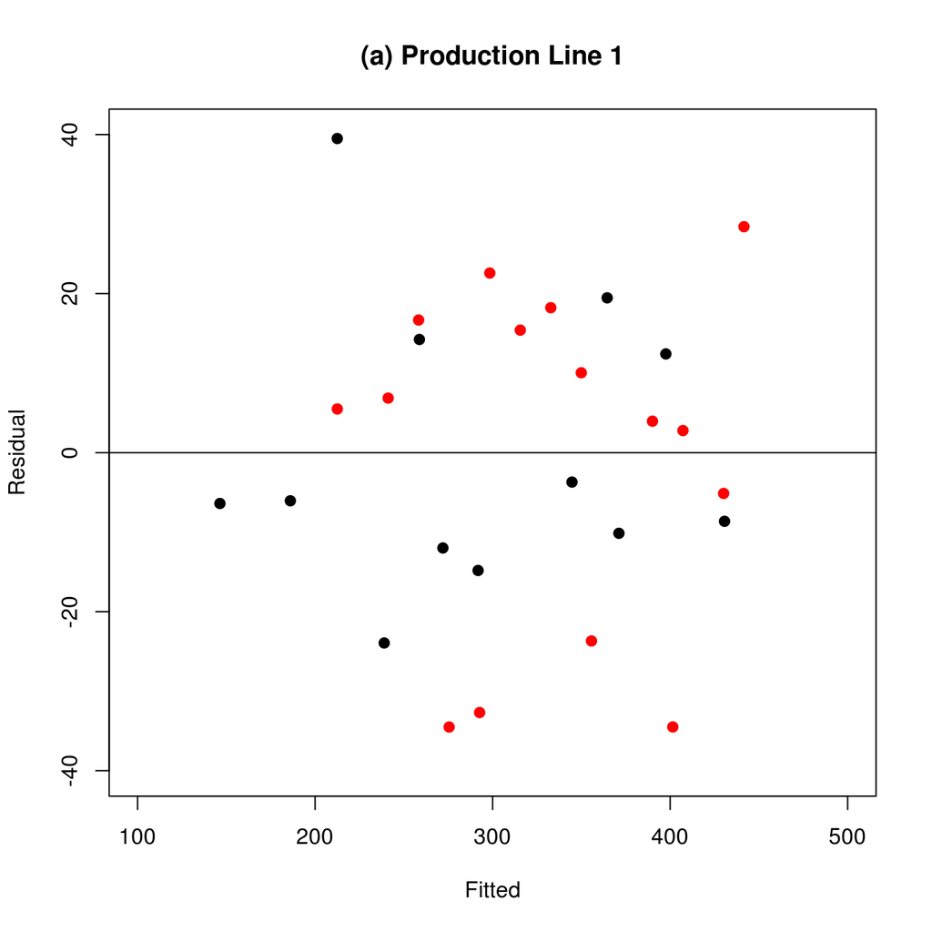

```r
plot(fitted(fit), resid(fit), col = .data$X2, pch = 19,
     xlim = c(100, 500), ylim = c(-40,40),
     ylab = "Residual", xlab = "Fitted")
title("(a) Production Line 1")
abline(0, 0)
```

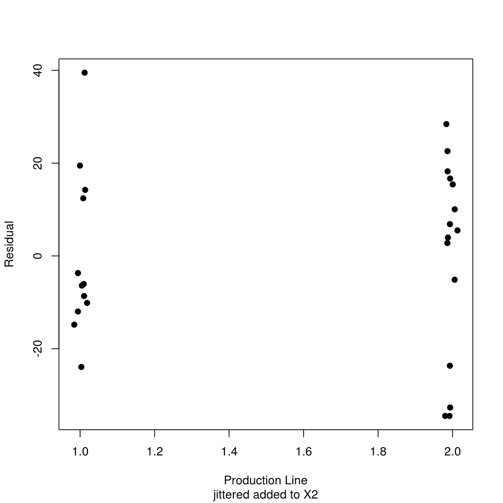

```r
plot(jitter(as.numeric(.data$X2), 0.1), resid(fit), pch = 19,
     xlab = "Production Line", ylab = "Residual", sub = "jittered added to X2")
```

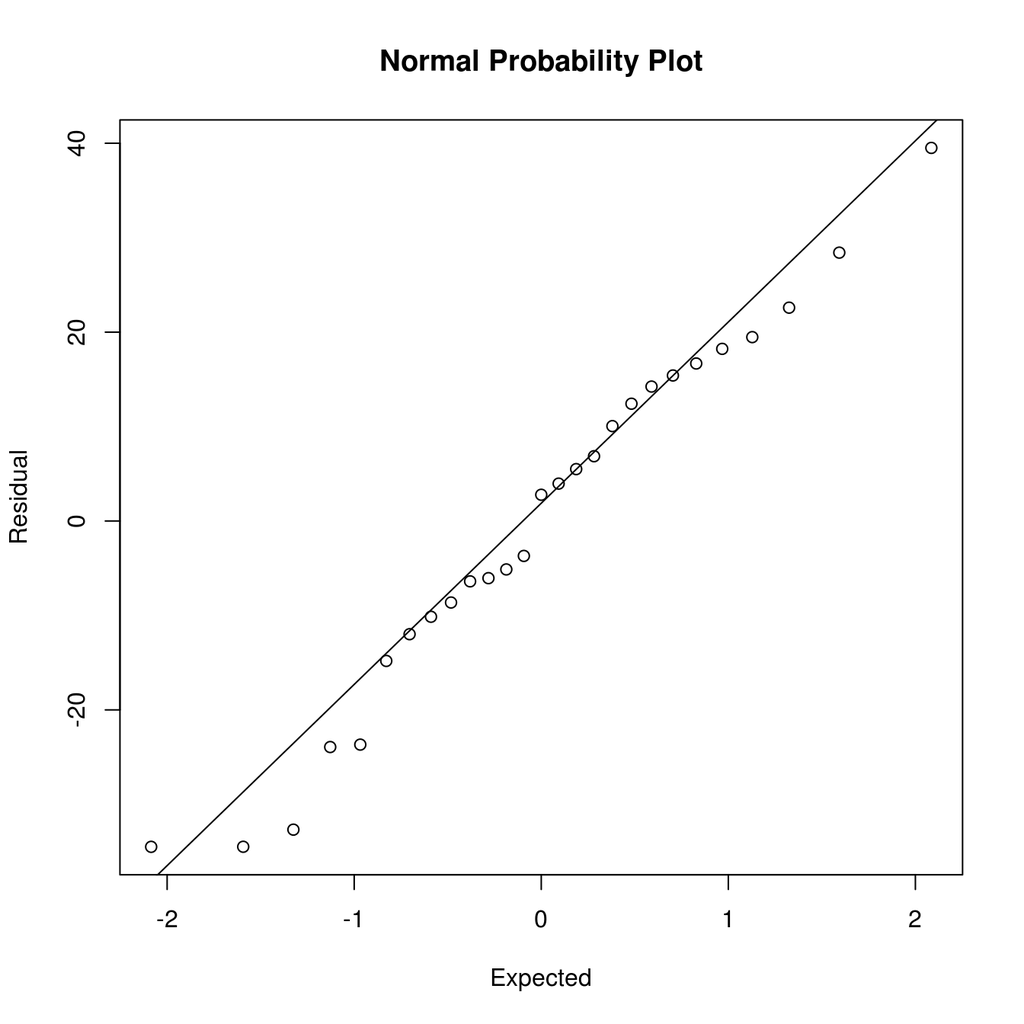

```r
qqnorm(resid(fit), xlab = "Expected", ylab = "Residual", main = "")
qqline(resid(fit))
title("Normal Probability Plot")
```

## TABLE 8.6 (p 332)

#### Regression Results for Fit of Regression Model (8.55)–Soap Production Lines Example

```r
fit <- lm(Y ~ X1 * X2, .data)  # No longer using the nested model
summary(fit)
```

```
##
## Call:
## lm(formula = Y ~ X1 * X2, data = .data)
##
## Residuals:
##    Min     1Q Median     3Q    Max
## -34.50 -11.06   2.78  14.82  39.51
##
## Coefficients:
##             Estimate Std. Error t value Pr(>|t|)
## (Intercept)   7.5745    20.8697    0.36   0.7200
## X1            1.3220     0.0926   14.27  6.4e-13 ***
## X2Line2      90.3909    28.3457    3.19   0.0041 **
## X1:X2Line2   -0.1767     0.1288   -1.37   0.1835
## ---
## Signif. codes:  0 '***' 0.001 '**' 0.01 '*' 0.05 '.' 0.1 ' ' 1
##
## Residual standard error: 20.8 on 23 degrees of freedom
## Multiple R-squared:  0.945,  Adjusted R-squared:  0.937
## F-statistic:  131 on 3 and 23 DF,  p-value: 1.34e-14
```

```r
anova(fit)
```

```
## Analysis of Variance Table
##
## Response: Y
##           Df Sum Sq Mean Sq F value  Pr(>F)
## X1         1 149661  149661  347.55 2.2e-15 ***
## X2         1  18694   18694   43.41 1.0e-06 ***
## X1:X2      1    810     810    1.88    0.18
## Residuals 23   9904     431
## ---
## Signif. codes:  0 '***' 0.001 '**' 0.01 '*' 0.05 '.' 0.1 ' ' 1
```